Software Product Mastering / Das unsichtbare Biest / Das "Was" und das "Wie" / Stacey Matrix / Cynefin-Modell / Softwarekomplexität seit 1980

# Conways law

| [Conway's Law - Wikipedia](https://en.wikipedia.org/wiki/Conway%27s_law) [Conway's Law - Martin Fowler](https://martinfowler.com/bliki/ConwaysLaw.html) [Was ist das Gesetz von Conway? - t2informatik](… |
| --- |

[figure not shown]

Quelle: https://www.facebook.com/flexbasedigital (9.11.2024)

Conways Gesetz besagt, dass die Struktur von Softwareprodukten oft die Kommunikationsstrukturen der Teams widerspiegelt, die sie entwickeln. Formuliert wurde es in den 1960er Jahren vom Informatiker Melvin Conway und kann zusammengefasst werden als:

> "Organisationen, die Systeme entwerfen, sind gezwungen, Systeme zu entwerfen, die Abbilder ihrer Kommunikationsstrukturen sind."

**Auswirkungen auf Softwareprodukte**:

- **Architekturelle Abhängigkeiten**: Isolierte Module und Silos, die schwerfällig und komplex sein können.
- **Wartbarkeit und technische Schuld**: Schwierige Anpassungen und Risiko technischer Schuld durch enge Abhängigkeiten.
- **Innovation und Geschwindigkeit**: Starre Strukturen hemmen Innovation; agile Kommunikation fördert Flexibilität.
- **Microservices und DevOps**: Unterstützen das Gesetz durch autonom agierende, funktionsübergreifende Teams.
- **Nutzererfahrung und Produktqualität**: Schlechte Abstimmung zwischen Teams kann zu inkonsistenter Nutzererfahrung führen.

**Strategien zur positiven Nutzung**:

- **Cross-funktionale Teams**: Teams mit allen nötigen Kompetenzen minimieren Abhängigkeiten.
- **Optimierte Kommunikation**: Regelmäßiger Austausch und Meeting-Formate wie "Cross Team Daily".
- **Produktorientierte Teamstrukturen**: Teams entsprechend der Softwaremodule organisieren.

## Conways Gesetz in Bildern

### Beispiele (mit Augenzwinkern)

[figure not shown]

Quelle: https://www.kassenzone.de/conways-law/ (9.11.2024)

### Realtität versus Planung (mit Augenzwinkern)

[figure not shown]

Quelle: https://www.dcme.nu/conways-law/ (9.11.2024)

**Nochmal zum Nachlesen...**

Das bedeutet, dass sich in Softwarearchitekturen oft dieselben Hierarchien, Schnittstellen und Abgrenzungen finden lassen, die in den Entwicklungsabteilungen existieren. Eine Firma mit stark separierten Abteilungen (z. B. Frontend- und Backend-Teams) neigt also dazu, auch ihre Software in deutlich abgegrenzte Frontend- und Backend-Komponenten aufzuteilen.

### Auswirkungen von Conways Gesetz auf Softwareprodukte

1. **Architekturelle Abhängigkeiten**:
   - Wenn Teams stark voneinander getrennt arbeiten und nur wenig miteinander kommunizieren, entstehen oft „Silos“ in der Software. Diese Silos sind Module oder Services, die kaum Schnittstellen zu anderen Teilen des Systems haben und eher isoliert arbeiten.
   - Ein aufgeteiltes Team kann dazu führen, dass Systeme schwerfällig sind und die Schnittstellen zwischen Modulen komplex und starr. Dies wird in monolithischen Architekturen oft sichtbar.
2. **Wartbarkeit und technische Schuld**:
   - Systeme, die stark nach den Teamstrukturen aufgebaut sind, haben oft komplizierte Abhängigkeiten. Es kann sein, dass Änderungen oder Erweiterungen der Software erschwert werden, weil es schwierig ist, das Gesamtbild zu durchschauen.
   - Technische Schuld kann entstehen, wenn über Jahre hinweg Softwarestrukturen lediglich den Kommunikationsstrukturen folgen, statt modular und agil auf neue Anforderungen reagieren zu können.
3. **Innovation und Geschwindigkeit**:
   - Kommunikationsstruktur hat einen Einfluss auf die Innovationsfähigkeit eines Teams. In einem stark fragmentierten Unternehmen, in dem sich Teams selten austauschen, kommt es zu weniger Innovation. Die Modularität wird oft nicht genutzt, und die Geschwindigkeit, in der ein Team auf Feedback reagieren kann, sinkt.
   - Ist die Kommunikation agil und offen, sind auch die Produkte oft flexibler und modular aufgebaut, sodass neue Ideen und Features schneller umgesetzt werden können.
4. **Microservices und DevOps**:
   - Conways Gesetz hat in der Microservices- und DevOps-Ära an Bedeutung gewonnen, da diese Ansätze selbstorganisierende, funktionsübergreifende Teams fördern. Jedes Team kann Verantwortung für einen bestimmten Service übernehmen, was zu einer modulareren und wartbaren Architektur führt.
   - Die unabhängigen Microservices spiegeln dabei die Kommunikationsstruktur der Teams wider und sind in sich geschlossene Einheiten, die autonom entwickelt und skaliert werden können.
5. **Einfluss auf Nutzererfahrung und Produktqualität**:
   - Ein schlecht abgestimmtes Team-Setup kann die Nutzererfahrung beeinflussen. Wenn z. B. das Frontend-Team nicht eng mit dem Backend-Team kommuniziert, können unterschiedliche Interpretationen der Anwendungslogik oder der Benutzerführung entstehen, was die Qualität und Konsistenz beeinträchtigen kann.

### Praktische Ansätze, um Conways Gesetz positiv zu nutzen

- **Cross-funktionale Teams aufbauen**: Teams sollten alle notwendigen Kompetenzen abdecken, um eigenverantwortlich Features oder Module zu entwickeln. Damit wird die Softwarearchitektur modularer, und die Abhängigkeiten zwischen Teams und Modulen werden minimiert.
- **Kommunikationswege optimieren**: Regelmäßiger Austausch, z. B. in Form von „Cross Team Dailys“ (wie in deinem Fall geplant), kann helfen, einheitliche Ziele zu verfolgen und Blocker zu identifizieren, die die Produktentwicklung behindern.
- **Teamstrukturen nach dem Produktdesign aufbauen**: Statt die Teamstrukturen willkürlich zu gestalten, kann eine Ausrichtung an den geplanten Softwaremodulen sinnvoll sein. So wird sichergestellt, dass die Architektur der Software stabil und konsistent bleibt, während sie sich den Benutzeranforderungen anpasst.

Conways Gesetz zu berücksichtigen, bedeutet also, die Teamstrukturen bewusst so zu gestalten, dass sie die gewünschte Produktarchitektur und Qualität begünstigen.

## Conways law spielerisch kennenlernen

Ein spielerisches Programm könnte Teams und Softwaremodule simulieren, um Conways Gesetz praktisch erfahrbar zu machen. Dabei könnte eine interaktive Simulation helfen, die zeigt, wie verschiedene Teamstrukturen die resultierende Softwarearchitektur beeinflussen. Am Ende könnte man den Zusammenhang visualisieren und durch einen Code-Anwendungsfall verdeutlichen.

Hier ein Beispiel:

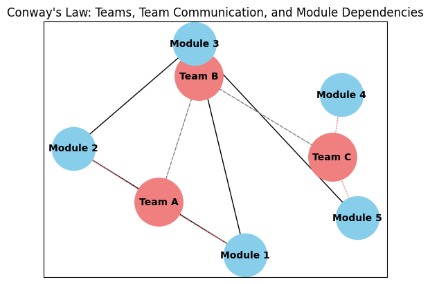

```python
import networkx as nx
import matplotlib.pyplot as plt

# Definiere die Teams und die ihnen zugeordneten Module
teams = {
    "Team A": ["Module 1", "Module 2"],
    "Team B": ["Module 3"],
    "Team C": ["Module 4", "Module 5"]
}

# Definiere die Kommunikationsstruktur zwischen den Teams
communication = {
    "Team A": ["Team B"],
    "Team B": ["Team C"],
    "Team C": []
}

# Definiere die Abhängigkeiten zwischen Modulen
module_dependencies = {
    "Module 1": ["Module 2", "Module 3"],
    "Module 2": ["Module 3"],
    "Module 3": ["Module 5"],
    "Module 4": [],
    "Module 5": []
}

# Visualisierung der Teamkommunikation und Modulabhängigkeiten
def visualize_conways_law(teams, communication, module_dependencies):
    G = nx.DiGraph()

    # Füge Teams als separate Knoten hinzu
    for team in teams:
        G.add_node(team, color="lightcoral")  # Teamknoten

    # Füge Module und Zuordnung zu den Teams hinzu
    for team, modules in teams.items():
        for module in modules:
            G.add_node(module, color="skyblue")  # Moduleknoten
            G.add_edge(team, module, style="dotted", color="lightcoral")  # Verbindung Team zu Modul

    # Füge Abhängigkeiten zwischen Modulen hinzu (solid lines)
    solid_edges = []
    for module, dependencies in module_dependencies.items():
        for dependency in dependencies:
            solid_edges.append((dependency, module))

    # Füge Kommunikationslinien zwischen Teams hinzu (dashed lines)
    dashed_edges = []
    for team, neighbors in communication.items():
        for neighbor in neighbors:
            dashed_edges.append((team, neighbor))

    # Visualisierung der Struktur
    pos = nx.spring_layout(G)

    # Zeichne die Teams als separate Knoten
    team_nodes = [node for node in G.nodes if node in teams]
    module_nodes = [node for node in G.nodes if node not in teams]

    nx.draw_networkx_nodes(G, pos, nodelist=team_nodes, node_size=2500, node_color="lightcoral", label="Teams")
    nx.draw_networkx_nodes(G, pos, nodelist=module_nodes, node_size=2000, node_color="skyblue", label="Modules")

    # Zeichne die Labels für Teams und Module
    nx.draw_networkx_labels(G, pos, font_size=10, font_weight="bold")

    # Zeichne die verschiedenen Kantentypen (Team-Kommunikation und Modulabhängigkeiten)
    nx.draw_networkx_edges(G, pos, edgelist=solid_edges, style="solid", edge_color="black", label="Module Dependencies")
    nx.draw_networkx_edges(G, pos, edgelist=dashed_edges, style="dashed", edge_color="gray", label="Team Communication")

    # Zeichne die Verbindungen zwischen Teams und ihren Modulen (dotted lines)
    dotted_edges = [(team, module) for team in teams for module in teams[team]]
    nx.draw_networkx_edges(G, pos, edgelist=dotted_edges, style="dotted", edge_color="lightcoral", label="Team to Module Assignment")

    plt.title("Conway's Law: Teams, Team Communication, and Module Dependencies")
    plt.show()

visualize_conways_law(teams, communication, module_dependencies)
```

### Erklärung der Visualisierung

- **Teams (lightcoral)**: Teams sind als separate Knoten dargestellt.
- **Module (skyblue)**: Module sind ebenfalls als separate Knoten sichtbar.
- **Team-Kommunikation (gestrichelte, graue Linien)**: Verbindungen zwischen Teams zeigen, welche Teams miteinander kommunizieren.
- **Modulabhängigkeiten (durchgezogene, schwarze Linien)**: Zeigt Abhängigkeiten zwischen Modulen an, die unterschiedliche Teams betreffen können.
- **Team-Modul-Zuordnung (gepunktete, hellrote Linien)**: Verbindet Teams mit ihren Modulen, um die Teamstruktur visuell darzustellen.